# Introduction to R

2021-06-14

### Workshop Overview

**Teaching**: 40 minutes  
**Exercises**: 10 minutes

**Guiding Questions**:

What data types are available in R? What is an object? How can values be initially assigned to variables of different data types?  
What arithmetic and logical operators can be used?  
How can subsets be extracted from vectors?  
How does R treat missing values?  
How can we deal with missing values in R?

**Lesson Objectives**:

Define the following terms as they relate to R: object, assign, call, function, arguments, options.  
Assign values to objects in R.  
Learn how to name objects.  
Use comments to inform script.  
Solve simple arithmetic operations in R.  
Call functions and use arguments to change their default options.  
Inspect the content of vectors and manipulate their content.

### Running code in R

There are two main ways of interacting with R: by using the console or by using script files (plain text files that contain your code). The console pane (in RStudio, the bottom left panel) is the place where commands written in the R language can be typed and executed immediately by the computer. It is also where the results will be shown for commands that have been executed. You can type commands directly into the console and press `Enter` to execute those commands, but they will be forgotten when you close the session.

Because we want our code and workflow to be reproducible, it is better to type the commands we want in the script editor and save the script. This way, there is a complete record of what we did, and anyone (including our future selves!) can easily replicate the results on their computer.

RStudio allows you to execute commands directly from the script editor by using the `Ctrl` + `Enter` shortcut (on Mac, `Cmd` + `Return` will work). The command on the current line in the script (indicated by the cursor) or all of the commands in selected text will be sent to the console and executed when you press `Ctrl` + `Enter`. If there is information in the console you do not need anymore, you can clear it with `Ctrl` + `L`. You can find other keyboard shortcuts in this [RStudio cheatsheet about the RStudio IDE](https://github.com/rstudio/cheatsheets/raw/master/rstudio-ide.pdf).

### Using R as a calculator

The simplest thing you could do with R is to do arithmetic.

**Practice**: Enter each of the following commands and confirm that the response is the correct answer.

```r
1 + 2
16*9
sqrt(2)
20/5
18.5 - 7.21
3 %% 2 ## what is this doing?
```

### Creating objects

These operations, however, are not very interesting. To do more useful things in R, we need to assign values to an object. To create an object, we tell R the object’s name, followed by an assignment arrow (`<-`), and finally the value of the object. This would look something like this:

`x <- 6`

Once we execute/run this line of code, we notice that a new object appears in our environment window. This window shows all of the objects that you have created during your R session. The value of `x` appears next to it, since it is a scalar.

**Remarks:**

- In the above code `<-` is the assignment operator. It assigns values on the right to objects on the left. So, after executing `year <- 2006`, the value of `year` is `2006`. The arrow can be read as `2006` goes into `year`. For historical reasons, you can also use = for assignments, but not in every context. Because of the slight differences in syntax, it is best practice to always use `<-` for assignments.
  - In RStudio, typing `Alt` + `-` (push `Alt` at the same time as the `-` key) will write `<-` in a single keystroke in a PC, while typing `Option` + `-` (push `Option` at the same time as the `-` key) does the same in a Mac.
- There are a few simple rules that apply when creating the same of a new object (like we did above):
  - R is case sensitive, so if you name your variable `cat` but then try to run the code `Cat + 2`, you will get an error saying that `Cat` does not exist
  - You also want your object’s name to be explanatory, but not too long. Think `current_temperature` verses `current_temp`. Do you really want to type out temperature every time?
  - Finally, you cannot begin any object’s name with a number. You can end a name with a number (e.g. clean_data2), but does that give you much information about what is in the contents of `clean_data2` relative to `clean_data`?
  - The name cannot contain any punctuation symbols, except for `.` and `_` (`.` is not recommended)
  - You should not name your object the same as any common functions you may use (`mean`, `sd,` etc.)
- Using a consistent coding style makes your code clearer to read for your future self and your collaborators. In R, three popular style guides are Google’s (https://google.github.io/styleguide/Rguide.html), Jean Fan’s (https://jef.works/R-style-guide/) and the tidyverse’s (https://style.tidyverse.org/). The tidyverse’s is very comprehensive and may seem overwhelming at first, but you’d be surprised what good code writing habits can do for your collaborations!

## A note on objects vs. variables

> What are known as `objects` in R are known as `variables` in many other programming languages. Depending on the context, `object` and `variable` can have drastically different meanings. However, in this lesson, the two words are used synonymously. For more information see: https://cran.r-project.org/doc/manuals/r-release/R-lang.html#Objects

When assigning a value to an object, R does not print anything. You can force R to print the value by using parentheses or by typing the object name:

```r
year <- 2016    # doesn't print anything
(year <- 2016)  # putting parenthesis around the call prints the value of year
```

```
[1] 2016
```

```r
year         # and so does typing the name of the object
```

```
[1] 2016
```

Now that R has `year` in memory, we can do arithmetic with it. For instance, we may want to find the number of years after 1989 it is:

```r
year - 1989
```

```
[1] 27
```

We can also change an object’s value by assigning it a new one:

```r
year <- 2005
year - 1989
```

```
[1] 16
```

```r
years_post_birthday <- year - 1989
```

and then change `year` to 2002.

```r
year <- 2002
```

### Your turn!

### Exercise

What do you think is the current content of the object `years_post_birthday`? 16 or 13?

### Solution

The value of `years_post_birthday` is still 16 because you have not re-run the line `years_post_birthday <- year - 1989` since changing the value of `year`.

### Adding code comments

All programming languages allow the programmer to include comments in their code. To do this in R we use the `#` character. Anything to the right of the `#` sign and up to the end of the line is treated as a comment and is ignored by R. You can start lines with comments or include them after any code on the line.

```r
ms_year <- 2016    # Year got M.S.
phd_year <- ms_year + 4 # Year got Ph.D.
```

RStudio makes it easy to comment or uncomment a paragraph: after selecting the lines you want to comment, press at the same time on your keyboard `Ctrl` + `Shift` + `C`. If you only want to comment out one line, you can put the cursor at any location of that line (i.e. no need to select the whole line), then press `Ctrl` + `Shift` + `C`.

### Your turn!

### Exercise

Create two variables `length` and `width` and assign them values. It should be noted that, because `length` and `width` are built-in R functions, R Studio might add “()” after length and width and if you leave the parentheses you will get unexpected results. This is why you might see other programmers abbreviate common words.

Create a third variable `area` and give it a value based on the current values of `length` and `width`.

Show that changing the values of either `length` and `width` does not affect the value of `area`.

### Solution

```r
length <- 2.5
width <- 3.2
area <- length * width
area
```

```
[1] 8
```

```r
# change the values of length and width
length <- 7.0
width <- 6.5
# the value of area isn't changed
area
```

```
[1] 8
```

### Functions and their arguments

Functions are “canned scripts” that automate more complicated sets of commands including operations assignments, etc. Many functions are predefined, or can be made available by importing R *packages* (more on that later). A function usually gets one or more inputs called *arguments*. Functions often (but not always) return a *value*. A typical example would be the function `sqrt()`. The input (the argument) must be a number, and the return value (in fact, the output) is the square root of that number. Executing a function (‘running it’) is called *calling* the function. An example of a function call is:

```r
b <- sqrt(a)
```

Here, the value of `a` is given to the `sqrt()` function, the `sqrt()` function calculates the square root, and returns the value which is then assigned to the object `b`. This function is very simple, because it takes just one argument.

The return ‘value’ of a function need not be numerical (like that of `sqrt()`), and it also does not need to be a single item: it can be a set of things, or even a dataset. We’ll see that when we read data files into R.

Arguments can be anything, not only numbers or filenames, but also other objects. Exactly what each argument means differs per function, and must be looked up in the documentation (see below). Some functions take arguments which may either be specified by the user, or, if left out, take on a *default* value: these are called *options*. Options are typically used to alter the way the function operates, such as whether it ignores ‘bad values’, or what symbol to use in a plot. However, if you want something specific, you can specify a value of your choice which will be used instead of the default.

Let’s try a function that can take multiple arguments: `round()`

```r
round(3.14159)
```

```
[1] 3
```

Here, we’ve called `round()` with just one argument, `3.14159`, and it has returned the value `3`. That’s because the default is to round to the nearest whole number. If we want more digits we can see how to do that by getting information about the `round()` function. We can use `args(round)` or look at the help for this function using `?round`.

```r
args(round)
```

```
function (x, digits = 0)
NULL
```

```r
?round
```

We see that if we want a different number of digits, we can type `digits = 2` or however many we want.

```r
round(3.14159, digits = 2)
```

```
[1] 3.14
```

If you provide the arguments in the exact same order as they are defined you don’t have to name them:

```r
round(3.14159, 2)
```

```
[1] 3.14
```

And if you do name the arguments, you can switch their order:

```r
round(digits = 2, x = 3.14159)
```

```
[1] 3.14
```

But if you don’t name the arguments, you can’t switch their order:

```r
round(2, 3.14159)
```

```
[1] 2
```

It’s good practice to put the non-optional arguments (like the number you’re rounding) first in your function call, and to specify the names of all optional arguments. If you don’t, someone reading your code might have to look up the definition of a function with unfamiliar arguments to understand what you’re doing.

### Your turn!

### Exercise

Type in `?round` at the console and then look at the output in the Help pane. What other functions exist that are similar to `round`? How do you use the `digits` parameter in the round function?

### Vectors and data types

A vector is the most common and basic data type in R, and is pretty much the workhorse of R. A vector is composed by a series of values, which can be either numbers or characters. We can assign a series of values to a vector using the `c()` function. For example we can create a vector of years in the 1990s and assign it to a new object `years_90s`:

```r
years_90s <- c(1990, 1991, 1992, 1993, 1994, 1995, 1996, 1997, 1998, 1999)
years_90s
```

```
 [1] 1990 1991 1992 1993 1994 1995 1996 1997 1998 1999
```

A vector can also contain characters. For example, we can have a vector of country names:

```r
countries <- c("Beligum", "Denmark", "Germany", "France")
countries
```

```
[1] "Beligum" "Denmark" "Germany" "France"
```

The quotes around “Belgium”, etc. are essential here. Without the quotes R will assume there are objects called `Beligum`, `Denmark`, `Germany`, and `France`. As these objects don’t exist in R’s memory, there will be an error message:

```r
countries <- c(Beligum, Denmark, Germany, France)
```

```
Error in eval(expr, envir, enclos): object 'Beligum' not found
```

### Inspecting objects

There are many functions that allow you to inspect the content of a vector. `length()` tells you how many elements are in a particular vector:

```r
length(years_90s)
```

```
[1] 10
```

```r
length(countries)
```

```
[1] 4
```

An important feature of a vector, is that all of the elements are the same type of data. The function `class()` indicate the class (the type of element) of an object:

```r
class(years_90s)
```

```
[1] "numeric"
```

```r
class(countries)
```

```
[1] "character"
```

The function `str()` provides an overview of the structure of an object and its elements. It is a useful function when working with large and complex objects:

```r
str(years_90s)
```

```
 num [1:10] 1990 1991 1992 1993 1994 ...
```

```r
str(countries)
```

```
 chr [1:4] "Beligum" "Denmark" "Germany" "France"
```

You can use the `c()` function to add other elements to your vector:

```r
possessions <- c("bicycle", "radio", "television")
possessions <- c(possessions, "mobile_phone") # add to the end of the vector
possessions <- c("car", possessions) # add to the beginning of the vector
possessions
```

```
[1] "car"          "bicycle"      "radio"        "television"   "mobile_phone"
```

In the first line, we take the original vector `possessions`, add the value `"mobile_phone"` to the end of it, and save the result back into `possessions`. Then we add the value `"car"` to the beginning, again saving the result back into `possessions`.

We can do this over and over again to grow a vector, or assemble a dataset. As we program, this may be useful to add results that we are collecting or calculating.

An **atomic vector** is the simplest R **data type** and is a linear vector of a single type. Above, we saw 2 of the 6 main **atomic vector** types that R uses: `"character"` and `"numeric"` (or `"double"`). These are the basic building blocks that all R objects are built from. The other 4 **atomic vector** types are:

- `"logical"` for `TRUE` and `FALSE` (the boolean data type)
- `"integer"` for integer numbers (e.g., `2L`, the `L` indicates to R that it’s an integer)
- `"complex"` to represent complex numbers with real and imaginary parts (e.g., `1 + 4i`) and that’s all we’re going to say about them
- `"raw"` for bitstreams that we won’t discuss further

You can check the type of your vector using the `typeof()` function and inputting your vector as the argument.

Vectors are one of the many **data structures** that R uses. Other important ones are lists (`list`), matrices (`matrix`), data frames (`data.frame`), factors (`factor`) and arrays (`array`).

### Your turn!

## Exercises

### Exercise 1

We’ve seen that atomic vectors can be of type character, numeric (or double), integer, and logical. But what happens if we try to mix these types in a single vector?

### Exercise 2

What will happen in each of these examples? (hint: use `class()` to check the data type of your objects):

```r
num_char <- c(1, 2, 3, "a")
num_logical <- c(1, 2, 3, TRUE)
char_logical <- c("a", "b", "c", TRUE)
tricky <- c(1, 2, 3, "4")
```

Why do you think it happens?

### Exercise 3

How many values in `combined_logical` are `"TRUE"` (as a character) in the following example:

```r
num_logical <- c(1, 2, 3, TRUE)
char_logical <- c("a", "b", "c", TRUE)
combined_logical <- c(num_logical, char_logical)
```

### Solution 1

R implicitly converts them to all be the same type.

### Solution 2

Vectors can be of only one data type. R tries to convert (coerce) the content of this vector to find a “common denominator” that doesn’t lose any information.

### Solution 3

Only one. There is no memory of past data types, and the coercion happens the first time the vector is evaluated. Therefore, the `TRUE` in `num_logical` gets converted into a `1` before it gets converted into `"1"` in `combined_logical`.

You’ve probably noticed that objects of different types get converted into a single, shared type within a vector. In R, we call converting objects from one class into another class *coercion*. These conversions happen according to a hierarchy, whereby some types get preferentially coerced into other types.

**Can you draw a diagram that represents the hierarchy of how these data types are coerced?**

### Lists

While the elements of vectors have to be of the same data type, a list is a special vector in `R` that allows for you to store a variety of types of objects. If you have a vector, a matrix, a character, you can store all of them into one list object!

```r
my_first_list <- list(years_90s, countries)
my_first_list
```

```
[[1]]
 [1] 1990 1991 1992 1993 1994 1995 1996 1997 1998 1999

[[2]]
[1] "Beligum" "Denmark" "Germany" "France"
```

We notice that when printing a list, the output looks a bit different. There are a whole bunch of brackets! Let’s break them down. I like to think of a list as a shelf with cubby holes. The cubby holes are the components of the list, but there are elements in each cubby.

- To get to a specific component (cubby) of a list, you use the double brackets next to the name of the list (e.g `my_first_list[[1]]`).
- To access the elements inside each cubby, you then use single square brackets (e.g. `my_first_list[[1]][2]`).

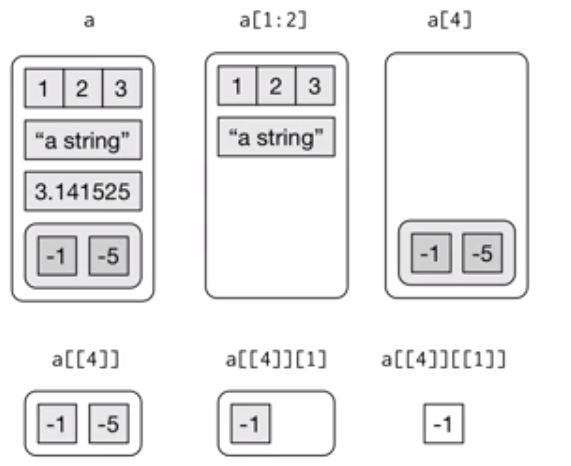

### Named Lists

```r
my_named_list <- list(title = "statistics",
                      numbers = 1:10,
                      data = TRUE)
my_named_list
```

```
$title
[1] "statistics"

$numbers
 [1]  1  2  3  4  5  6  7  8  9 10

$data
[1] TRUE
```

We see the output for a named list is slightly different. Instead of double brackets next to each component, there are now `$` and names of the variable. This will help you understand the structure of data.frames (coming up next)!

### Dataframes